# 分析設計

《学修項目》

- ◎データ分析の進め方、仮説検証サイクル、分析⽬的の設定
- データの収集、加⼯、統合
- 様々なデータ可視化⼿法（量的データを中心として）
- 基本統計量と相関係数

《キーワード》

> 仮説検証サイクル、分析目的の設定、データの収集・加工・分割／統合データの集計、前処理、ソート、欠損値の扱い、外れ値処理、比較対象の設定、さまざまなデータ可視化手法、量的データ、ヒストグラム、箱ひげ図、散布図、ヒートマップ、分割表とクロス集計、代表値、相関係数

《参考文献，参考書籍》

- [1] [東京大学MIセンター公開教材 「1-2 分析設計」](http://www.mi.u-tokyo.ac.jp/pdf/1-2_analysis_design.pdf) [《利用条件CC BY-NC-SA》](https://creativecommons.org/licenses/by-nc-sa/4.0/deed.ja)
- [2] [応用基礎としてのデータサイエンス（講談社 データサイエンス入門シリーズ）](https://www.kspub.co.jp/book/detail/5307892.html)
- [3] [データサイエンスの考え方 社会に役立つAI×データ活用のために（オーム社）](https://www.ohmsha.co.jp/book/9784274227974/)
- [4] [Pythonによるあたらしいデータ分析の教科書 第2版（翔泳社）](https://www.shoeisha.co.jp/book/detail/9784798178776)
- [5] [数理・データサイエンス・AI公開講座（放送大学）](https://www.ouj.ac.jp/booklet/2022/29_2022_MDS-AI.pdf)

## 1. データ分析の進め方 [1]

### 1.1 仮説検証サイクル [1]

データ分析によって全てがわかるわけではなく、仮説を立て、実験計画を立てて検証し、正しい場合は価値を見極め、新しい仮説を生み出すことが重要である。これは科学研究と同じ方法であり、データ分析の結果だけに頼らず、継続的に検証と改善を行う必要があるということである。

仮説検証サイクルは、経営学でよく使われる [PDCAサイクル（Plan-Do-Check-Action）](https://www.nri.com/jp/knowledge/glossary/lst/alphabet/pdca) と同じであり、計画、実行、評価、対策のプロセスを繰り返していくことが重要である。データ分析を行った結果、自分が考えたこととは異なる結果になることが多々あるため、仮説を修正したり、新たな仮説を立てたりする必要がある。

[figure not shown]

- [Caitlin Smallwood (Netflix) | How Netflix Data Science Powers Global Entertainment (タイムライン4:05から)](https://www.youtube.com/watch?v=0CGQvdAbNcc#t=4m05s)

### 1.2 分析目的の設定 [1]

[figure not shown]

- [KUROCO | データ分析とは？目的や正しいプロセス、手法、活用事例を解説（データ分析は「目的設定」が９割）](https://kuroco.team/blog-data-mokuteki/)

## 2. データの収集、加工、統合

### 2.1 データの種類、データのオーダ、前処理、欠損値の処理、外れ値の処理

#### 2.1.1 データの種類

構造化データ

- 分析できる形に構造化されたデータ
- 表形式で整理されたデータセット

→量的データ，質的データに分類される

非構造化データ

- まだ構造化されていないデータ

→ 画像，音声，文章データなど ※DE概論/データ表現の章を参照

#### 2.1.2 データのソート

- 順序付けの基準（オーダ）
  - 量的変数の場合：科目の得点など（間隔尺度（例：西暦年など），数値尺度（例：重量など）の別がある）
  - 質的変数の場合：名義尺度（学生名など），順序尺度（学籍番号など．順序が存在し，数量によるソートが可能）
- 昇順と逆順
  - 数値の大小で順序付ける：質的変数も，順序尺度であれば可能
  - 名義尺度も あいうえお順，ABC順などで順序付け (aab < ac < adbc など文字列にもオーダがつけられる）

[figure not shown]

#### 2.1.3 データの前処理

データクレンジング，データクリーニング

- 破損したデータ，不正確なデータ，無関係のデータなどの処理
- 住所や名簿などをデータ分析可能な状態にすること

主なデータ前処理

- 欠損値処理
- 外れ値処理，異常値処理
- ノイズの除去

データの変換

- 前処理としてのデータの変換
- 型変換やスケーリング
- 正規化，標準化

[figure not shown]

#### 2.1.4 欠損値の扱い

欠損値を処理する一般的な方法

- 削除：列や行ごと削除する
- 平均置換：平均値で置き換える（当該レコードの信頼性が毀損する）
- 最頻値で置き換え：質的データに有効
- ダミー置換：ダミー変数（Unknown, Zeroなど）で置き換える

完全データ：全ての値が観測されているデータ 不完全データ：欠損が含まれているデータ

頻繁に欠損値が出現するが，量的データのモデルが既知の場合には，欠損データを予測可能な回帰モデルを作成し，逐次代入する方法がとられる（統計的数値補完）

- [参考：note.nkmk.me | pandasで欠損値NaNを除外（削除）・置換（穴埋め）・抽出](https://note.nkmk.me/python-pandas-nan-dropna-fillna/)

[figure not shown]

#### 2.1.5 外れ値処理，異常値処理

- 外れ値：通常とはかけ離れた値
  - 異常の大きい，小さいなど
- 外れ値処理
  - 一般的には「残す」

+異常値：存在し得ない値など（例：非常に小規模な図書館の入場者が100万人であることを示すデータ，など） * 欠損値と同じ扱いとする * 個別に吟味し，置き換えや削除を検討する

一般的に，データ件数，レコード数が非常に大きくなるど，欠損値・外れ値・異常値を含む可能性が高まる

[figure not shown]

### 2.2 Pythonによるデータ抽出の実装例

Pythonによる実装については，クラウド環境であれば Google colab.が即時使える． ローカルPC上の環境であれば，Windows，macOS，Linuxなどで各々別途インストール作業が必要となる． 詳細は [こちらの参考書籍付属の公開資料](https://github.com/tsjshg/pyalgdata/blob/master/README.md)を参照されたい。

- [Pythonで学ぶアルゴリズムとデータ構造（講談社） 公開資料](https://github.com/tsjshg/pyalgdata/blob/master/README.md)
- [Pythonチュートリアル | 3. 形式ばらない Python の紹介](https://docs.python.org/ja/3/tutorial/introduction.html)

#### 2.2.1 サンプルデータ

ChickWeight : 鶏の体重 weight[g]、日齢 Time（0..42日）、鶏のID Chick（1..50）、餌の種類 Diet （1..4） (n=577)

体重・日齢は量的変数、鶏のID・餌の種類は質的変数/名義尺度

[figure not shown]

- [The R Datasets Package | ChickWeight - Weight versus age of chicks on different diets](https://stat.ethz.ch/R-manual/R-devel/library/datasets/html/ChickWeight.html)
- [ChickWeight.csv download](https://github.com/selva86/datasets/blob/master/ChickWeight.csv)

#### 2.2.2 欠損値のあるレコードの検出

```python
# オリジナルのCSVデータを カレントディレクトリ直下のフォルダ（一時作業領域）へダウンロードする．
!wget -nc https://raw.githubusercontent.com/MDASH-shinshu/MDASH-T-DS/main/2/resources/ChickWeight_original.csv

# 欠損値，外れ値あり加工済CSVファイルもダウンロードする
!wget -nc https://raw.githubusercontent.com/MDASH-shinshu/MDASH-T-DS/main/2/resources/ChickWeight_error.csv

# wgetしなくても，Google colab.の左メニュー [ファイル] アイコンをクリックして，ブラウザへファイルをドラッグ＆ドロップしても可

# ファイル (ChickWeight_xxxxxxx.csv)がダウンロード・配置できたことを確認する
##!ls -al ./

# オリジナルと加工済ファイルの相違点を diff で確認しておく
!diff ChickWeight_original.csv ChickWeight_error.csv
```

```
--2023-04-02 06:34:08--  https://raw.githubusercontent.com/MDASH-shinshu/MDASH-T-DS/main/2/resources/ChickWeight_original.csv
Resolving raw.githubusercontent.com (raw.githubusercontent.com)... 185.199.108.133, 185.199.109.133, 185.199.110.133, ...
Connecting to raw.githubusercontent.com (raw.githubusercontent.com)|185.199.108.133|:443... connected.
HTTP request sent, awaiting response... 200 OK
Length: 6406 (6.3K) [text/plain]
Saving to: ‘ChickWeight_original.csv’

ChickWeight_origina 100%[===================>]   6.26K  --.-KB/s    in 0s

2023-04-02 06:34:08 (55.6 MB/s) - ‘ChickWeight_original.csv’ saved [6406/6406]

--2023-04-02 06:34:08--  https://raw.githubusercontent.com/MDASH-shinshu/MDASH-T-DS/main/2/resources/ChickWeight_error.csv
Resolving raw.githubusercontent.com (raw.githubusercontent.com)... 185.199.108.133, 185.199.109.133, 185.199.110.133, ...
Connecting to raw.githubusercontent.com (raw.githubusercontent.com)|185.199.108.133|:443... connected.
HTTP request sent, awaiting response... 200 OK
Length: 6408 (6.3K) [text/plain]
Saving to: ‘ChickWeight_error.csv’

ChickWeight_error.c 100%[===================>]   6.26K  --.-KB/s    in 0s

2023-04-02 06:34:08 (73.7 MB/s) - ‘ChickWeight_error.csv’ saved [6408/6408]

9c9
< 149,32,1,1
---
> 1490,32,1,1
14c14
< 49,4,2,1
---
> NaN,4,2,1
```

```python
# 欠損値，外れ値あり加工済CSVファイルをpandasで読み込んでデータフレームdfに格納
import pandas as pd
from IPython.display import display

df = pd.read_csv('ChickWeight_error.csv')
df.columns = ['weight','Time','Chick','Diet']

# インタラクティブ表示にして，　[Filter] > [Search by all fields:] に NaN で検索すると，欠損値を含むレコードの場所が分かる（データ行の番号をメモしておくこと）
# 外れ値（異常値）は、weightの下限に 1000 とか入れてやると探せるかも？
display(df)
```

|  | weight | Time | Chick | Diet |
| --- | --- | --- | --- | --- |
| 0 | 51.0 | 4 | 1 | 1 |
| 1 | 59.0 | 8 | 1 | 1 |
| 2 | 64.0 | 12 | 1 | 1 |
| 3 | 76.0 | 16 | 1 | 1 |
| 4 | 93.0 | 20 | 1 | 1 |
| ... | ... | ... | ... | ... |
| 572 | 175.0 | 28 | 50 | 4 |
| 573 | 205.0 | 32 | 50 | 4 |
| 574 | 234.0 | 36 | 50 | 4 |
| 575 | 264.0 | 40 | 50 | 4 |
| 576 | 264.0 | 42 | 50 | 4 |

577 rows × 4 columns

```python
# 行・列ごとに欠損値の個数をカウント
print(df.isnull().sum())
```

```
weight    1
Time      0
Chick     0
Diet      0
dtype: int64
```

```python
# 欠損値NaNが一つでも含まれる行を抽出
print(df[df.isnull().any(axis=1)])
```

```
    weight  Time  Chick  Diet
12     NaN     4      2     1
```

#### 2.2.3 外れ値のあるレコードの検出

```python
# numexprの version 2.8.5は queryにバグがあるので、バージョン指定でインストール場合 (2023.8.31 KW)
# 参考：https://github.com/pandas-dev/pandas/issues/54449
# !pip install numexpr==2.8.4
```

```python
# 分位数を指定する—df.quantile()

q = df['weight'].quantile(1- 0.001) # 分位数 上位0.1%に属するもの（調整してみよ）
print(q)

# local variable substitution syntaxを用いた方法（numexprの version 2.8.5は query にバグがあるので動かない） (2023.8.31 KW)
# df_quan = df.query('weight > @q') # queryを使って，外れ値となっているレコードを確認する

# dataframe自体の行抽出処理を使う方法 (2023.8.31 YM)
df_quan2 = df[df['weight'] > q] # queryを使って，外れ値となっているレコードを確認する
df_quan2
```

```
847.7250000000762
```

|  | weight | Time | Chick | Diet |
| --- | --- | --- | --- | --- |
| 7 | 1490.0 | 32 | 1 | 1 |

## 3. 基本的なデータ可視化手法（量的データを中心として） [2]

可視化の主な目的は「比較する」「構成を見る」「分布を見る」「変化を見る」の4つに分けらる。 表3.1は、可視化の目的とデータの尺度に応じて基本的なグラフを分類したものであり、それぞれのグラフ単独での目的に基づいて分類していることが明記されている（同じグラフを複数並べての比較は含まれていない） [2]。

表3.1 データの量質 x 目的ごとの可視化法（[2]より引用）

[figure not shown]

統計グラフを利用する際には、データの尺度や変数の数に留意する必要がある。表3.2では、これらに応じた可視化法が区分されている。量的データにはヒストグラムや箱ひげ図、質的データには円グラフや棒グラフがよく用いられる。また、量的データには散布図、質的データにはモザイクプロットやヒートマップがよく用いられる [2]。

表3.2 データの量質 x 変数の数ごとの可視化法（[2]より引用）

[figure not shown]

以下では、量的データを主な対象とし、可視化・観察・分析する手法のいくつかについて説明していく。

### 3.1 1変数 量的データの可視化

#### 3.1.1 ヒストグラム

ヒストグラムは度数分布表を棒グラフで表現したものであり、横軸の棒が階級を表し、幅が階級幅、面積が度数を表す。通常、棒の幅は等しく設定されるが、場合によっては異なる幅を用いる場合もある。ヒストグラムを作成する際には、適切な階級数の設定が必要であり、階級数が少ないと全体像を理解しにくいが、逆に多すぎても全体像を把握しにくくなる。適切な階級数を決定するためには、スタージェスの公式がよく用いられる [2]。 ここで$n$を対象の数であるとすると、階級の数$k$は以下で求めることができる。

$$k = \log_2 n + 1$$

[figure not shown]

#### 3.1.2 Pythonによるヒストグラム生成の実装例

```python
# オリジナルのCSVファイルをpandasで読み込んでデータフレームdfに格納
import pandas as pd
df = pd.read_csv('ChickWeight_original.csv')
df.columns = ['weight','Time','Chick','Diet']
##df.head()
```

```python
# スタージェスの公式によって、サンプルデータ ChickWeight の 階級数 $k$ を求めてみる
import math # mathライブラリをインポート

n = len(df) #データの個数を取得 i.e. データフレームdfの行数
print(n) #データの個数を表示

k = math.log(n, 2) #2を底にした対数関数の値を求める
print('{:.3f}'.format(k)) #小数点以下3位まで出力
```

```
577
9.172
```

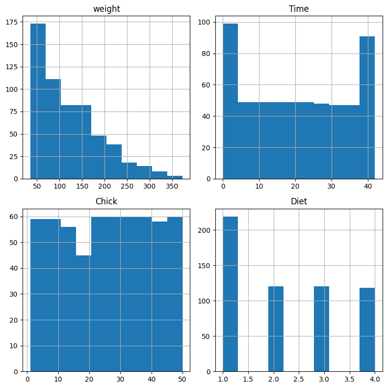

```python
# 4パラメータ全てで度数を観察してみる
import matplotlib.pyplot as plt
from pylab import rcParams
rcParams['figure.figsize'] = 8, 8
df.hist(); # 一括でヒストグラムを描画する（説明変数の指定無し）
plt.tight_layout() # グラフ同士が重ならないようにする関数
plt.show() # グラフの表示
```

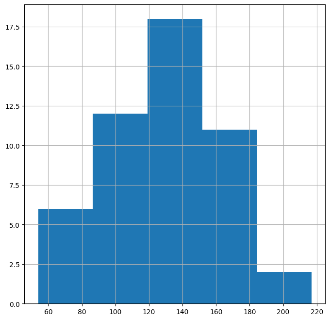

```python
# 階級数(基数)の数をkに変更し、具体的な日齢で抽出した度数を見てみる

df_select = df[df['Time'] == 24] # 日齢 24日の場合（変更してみよ 4の倍数であることに注意）
df_select['weight'].hist(bins=int(math.log(len(df_select), 2))); # 階級数k, 説明変数weight にしてヒストグラムを生成
plt.show()
```

#### 3.1.3 箱ひげ図

箱ひげ図は、データの最小値、第1四分位数、中央値、第3四分位数、最大値の5つの情報を可視化したグラフで、通常はひげが最小値と最大値を表し、箱の両端が四分位数を表す。ひげの長さは箱の長さの1.5倍として、ひげの外側のデータは外れ値として点で表されることもある。箱の中に中央値を示すことが一般的であるが、平均値を追加して表示することもある[2]。

[figure not shown]

#### 3.1.4 Pythonによる箱ひげ図生成の実装例

```
{'whiskers': [<matplotlib.lines.Line2D at 0x7ff0787bb520>,
 'caps': [<matplotlib.lines.Line2D at 0x7ff078759a90>,
 'boxes': [<matplotlib.lines.Line2D at 0x7ff0787bbdc0>,
 'medians': [<matplotlib.lines.Line2D at 0x7ff078754dc0>,
 'fliers': [<matplotlib.lines.Line2D at 0x7ff078754580>,
 'means': [<matplotlib.lines.Line2D at 0x7ff078754130>,
```

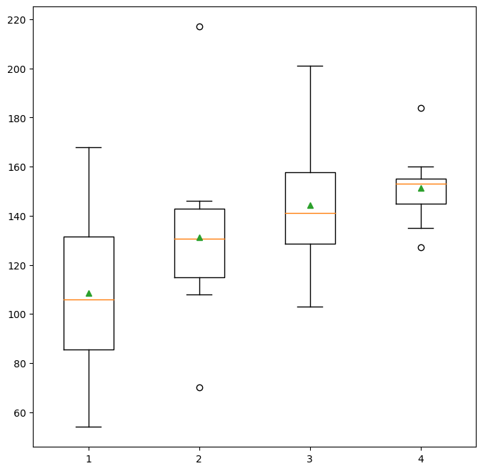

```python
# 日齢で抽出したdf_selectを使って、具体的な餌の種類 Diet毎の箱ひげ図を描画してみる(Diet毎にデータ生成しており効率が悪い)
df_Diet1 = df_select[df_select['Diet'] == 1]
df_Diet2 = df_select[df_select['Diet'] == 2]
df_Diet3 = df_select[df_select['Diet'] == 3]
df_Diet4 = df_select[df_select['Diet'] == 4]

plt.boxplot([df_Diet1['weight'], df_Diet2['weight'], df_Diet3['weight'], df_Diet4['weight']], showmeans=True)
```

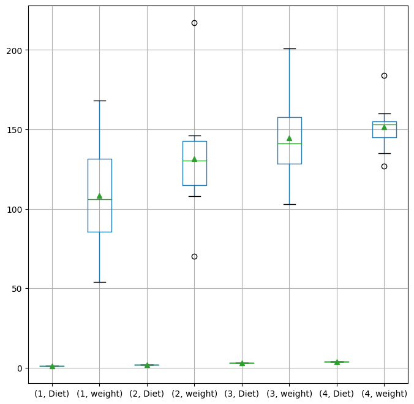

```python
# 日齢で抽出したdf_selectを使って、餌の種類 Diet毎にgroupbyを使って自動的に生成
grouped = df_select[['Diet','weight']].groupby('Diet')
##grouped.groups
grouped.boxplot(subplots=False, showmeans=True)
```

### 3.2 2変数・多変数 量的データの可視化

#### 3.2.1 散布図

量的な変数の可視化には、散布図または散布図行列がよく使われる。散布図は、2つの量的データを2次元空間にプロットしたもので、2つの変数間の関係を把握するために使用される。散布図は相関係数と密接な関係があり、主に相関関係の確認に使用されるが、外れ値の存在などデータの特徴を把握するためにも非常に有用である。

散布図行列は、複数の変数の組み合わせに対して散布図を作成する方法で、2次元空間に収まらない多次元データを可視化するために使用される。散布図行列には、各変数のヒストグラムが表示され、各変数間の相関関係を一度に確認することができる。

これらの可視化法は、データの特徴を直感的に理解するために非常に有用であり、データ解析の初期段階でよく使われまる。ただし、これらの手法には欠点もあり、例えば、散布図では非線形な関係を捉えることができないといった点がある。

[figure not shown]

#### 3.2.2 Pythonによる scikit-learn カリフォルニア住宅価格データセットの散布図生成

【参考】 [scikit-learn カリフォルニア住宅価格データの前処理に関する見解](https://qiita.com/kakiuchis/items/fb25c54af77df6e394ca)

```python
# scikit-learnからカリフォルニア住宅価格データ (n = 20640) を取得し、DESCRキーの情報を確認

import pandas as pd
import seaborn as sns
from sklearn.datasets import fetch_california_housing
dataset = fetch_california_housing()
print(dataset.DESCR)
```

```
.. _california_housing_dataset:

California Housing dataset
--------------------------

**Data Set Characteristics:**

    :Number of Instances: 20640

    :Number of Attributes: 8 numeric, predictive attributes and the target

    :Attribute Information:
        - MedInc        median income in block group
        - HouseAge      median house age in block group
        - AveRooms      average number of rooms per household
        - AveBedrms     average number of bedrooms per household
        - Population    block group population
        - AveOccup      average number of household members
        - Latitude      block group latitude
        - Longitude     block group longitude

    :Missing Attribute Values: None

This dataset was obtained from the StatLib repository.
https://www.dcc.fc.up.pt/~ltorgo/Regression/cal_housing.html

The target variable is the median house value for California districts,
expressed in hundreds of thousands of dollars ($100,000).

This dataset was derived from the 1990 U.S. census, using one row per census
block group. A block group is the smallest geographical unit for which the U.S.
Census Bureau publishes sample data (a block group typically has a population
of 600 to 3,000 people).

A household is a group of people residing within a home. Since the average
number of rooms and bedrooms in this dataset are provided per household, these
columns may take surprisingly large values for block groups with few households
and many empty houses, such as vacation resorts.

It can be downloaded/loaded using the
:func:`sklearn.datasets.fetch_california_housing` function.

.. topic:: References

    - Pace, R. Kelley and Ronald Barry, Sparse Spatial Autoregressions,
      Statistics and Probability Letters, 33 (1997) 291-297
```

```python
# DataFrameで実データを確認

df = pd.DataFrame(dataset.data, columns=dataset.feature_names)
df['Price'] = dataset.target
df.head()
```

|  | MedInc | HouseAge | AveRooms | AveBedrms | Population | AveOccup | Latitude | Longitude | Price |
| --- | --- | --- | --- | --- | --- | --- | --- | --- | --- |
| 0 | 8.3252 | 41.0 | 6.984127 | 1.023810 | 322.0 | 2.555556 | 37.88 | -122.23 | 4.526 |
| 1 | 8.3014 | 21.0 | 6.238137 | 0.971880 | 2401.0 | 2.109842 | 37.86 | -122.22 | 3.585 |
| 2 | 7.2574 | 52.0 | 8.288136 | 1.073446 | 496.0 | 2.802260 | 37.85 | -122.24 | 3.521 |
| 3 | 5.6431 | 52.0 | 5.817352 | 1.073059 | 558.0 | 2.547945 | 37.85 | -122.25 | 3.413 |
| 4 | 3.8462 | 52.0 | 6.281853 | 1.081081 | 565.0 | 2.181467 | 37.85 | -122.25 | 3.422 |

```python
# 基本情報を確認

df.describe()
```

|  | MedInc | HouseAge | AveRooms | AveBedrms | Population | AveOccup | Latitude | Longitude | Price |
| --- | --- | --- | --- | --- | --- | --- | --- | --- | --- |
| count | 20640.000000 | 20640.000000 | 20640.000000 | 20640.000000 | 20640.000000 | 20640.000000 | 20640.000000 | 20640.000000 | 20640.000000 |
| mean | 3.870671 | 28.639486 | 5.429000 | 1.096675 | 1425.476744 | 3.070655 | 35.631861 | -119.569704 | 2.068558 |
| std | 1.899822 | 12.585558 | 2.474173 | 0.473911 | 1132.462122 | 10.386050 | 2.135952 | 2.003532 | 1.153956 |
| min | 0.499900 | 1.000000 | 0.846154 | 0.333333 | 3.000000 | 0.692308 | 32.540000 | -124.350000 | 0.149990 |
| 25% | 2.563400 | 18.000000 | 4.440716 | 1.006079 | 787.000000 | 2.429741 | 33.930000 | -121.800000 | 1.196000 |
| 50% | 3.534800 | 29.000000 | 5.229129 | 1.048780 | 1166.000000 | 2.818116 | 34.260000 | -118.490000 | 1.797000 |
| 75% | 4.743250 | 37.000000 | 6.052381 | 1.099526 | 1725.000000 | 3.282261 | 37.710000 | -118.010000 | 2.647250 |
| max | 15.000100 | 52.000000 | 141.909091 | 34.066667 | 35682.000000 | 1243.333333 | 41.950000 | -114.310000 | 5.000010 |

```
array([[<Axes: title={'center': 'MedInc'}>,
        <Axes: title={'center': 'HouseAge'}>,
        <Axes: title={'center': 'AveRooms'}>],
       [<Axes: title={'center': 'AveBedrms'}>,
        <Axes: title={'center': 'Population'}>,
        <Axes: title={'center': 'AveOccup'}>],
       [<Axes: title={'center': 'Latitude'}>,
        <Axes: title={'center': 'Longitude'}>,
        <Axes: title={'center': 'Price'}>]], dtype=object)
```

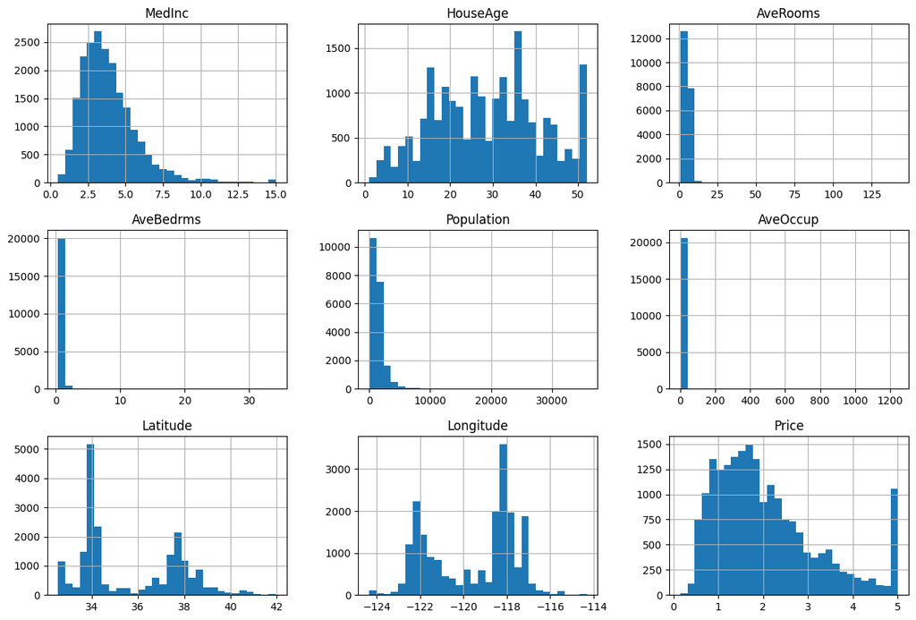

```python
# 各カラムの分布をヒストグラムで確認

df.hist(bins=30, figsize=(15, 10))
```

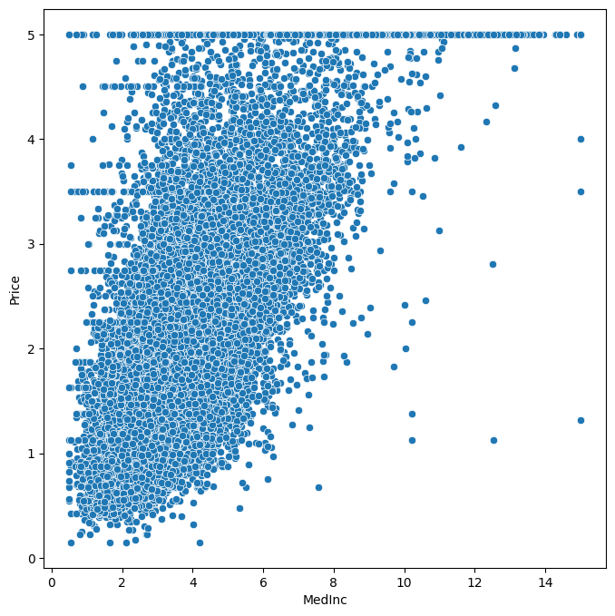

```python
# MedInc(ブロックの所得中央値), Price（住宅価格） の間で散布図を生成してみる (Seabornライブラリ利用)

sns.scatterplot(data=df, x='MedInc', y='Price')
```

#### 3.2.3 ヒートマップ

ヒートマップは、データの値を色や濃淡で表現したもので、クロス集計されたデータや行列の形で表される。また、地図などの空間に置かれた値の大きさを色や濃淡で表す場合もある。色を使って表現することで、数値で並べるよりも直感的に把握しやすくなる。

[figure not shown]

#### 3.2.4 Pythonによる 住宅価格を推定する問題のトレーニングデータ(Kaggle)のヒートマップ図生成

【参考】 [Kaggle | House Prices - Advanced Regression Techniques](https://www.kaggle.com/c/house-prices-advanced-regression-techniques)

```python
# CSVデータを カレントディレクトリ直下のフォルダ（一時作業領域）へダウンロードする．
!wget -nc https://raw.githubusercontent.com/MDASH-shinshu/MDASH-T-DS/main/2/resources/house_prices_train.csv

# wgetしなくても，Google colab.の左メニュー [ファイル] アイコンをクリックして，ブラウザへファイルをドラッグ＆ドロップしても可

# ファイル (house_prices_train.csv)がダウンロード・配置できたことを確認する
##!ls -al ./
```

```
--2023-04-02 06:34:14--  https://raw.githubusercontent.com/MDASH-shinshu/MDASH-T-DS/main/2/resources/house_prices_train.csv
Resolving raw.githubusercontent.com (raw.githubusercontent.com)... 185.199.108.133, 185.199.109.133, 185.199.110.133, ...
Connecting to raw.githubusercontent.com (raw.githubusercontent.com)|185.199.108.133|:443... connected.
HTTP request sent, awaiting response... 200 OK
Length: 460676 (450K) [text/plain]
Saving to: ‘house_prices_train.csv’

house_prices_train. 100%[===================>] 449.88K  --.-KB/s    in 0.03s

2023-04-02 06:34:15 (15.1 MB/s) - ‘house_prices_train.csv’ saved [460676/460676]
```

```python
# CSVファイルをpandasで読み込んでデータフレームdfに格納
import pandas as pd
df_house = pd.read_csv('house_prices_train.csv', index_col=0)

# pandas.DataFrameのメソッドcorr()を使うと、pandas.DataFrameの各列の間の相関係数を算出できる。
df_house_corr = df_house.corr()

print(df_house_corr.shape)
print(df_house_corr.head())
```

```
(37, 37)
             MSSubClass  LotFrontage   LotArea  OverallQual  OverallCond  \
MSSubClass     1.000000    -0.386347 -0.139781     0.032628    -0.059316
LotFrontage   -0.386347     1.000000  0.426095     0.251646    -0.059213
LotArea       -0.139781     0.426095  1.000000     0.105806    -0.005636
OverallQual    0.032628     0.251646  0.105806     1.000000    -0.091932
OverallCond   -0.059316    -0.059213 -0.005636    -0.091932     1.000000

             YearBuilt  YearRemodAdd  MasVnrArea  BsmtFinSF1  BsmtFinSF2  ...  \
MSSubClass    0.027850      0.040581    0.022936   -0.069836   -0.065649  ...
LotFrontage   0.123349      0.088866    0.193458    0.233633    0.049900  ...
LotArea       0.014228      0.013788    0.104160    0.214103    0.111170  ...
OverallQual   0.572323      0.550684    0.411876    0.239666   -0.059119  ...
OverallCond  -0.375983      0.073741   -0.128101   -0.046231    0.040229  ...

             WoodDeckSF  OpenPorchSF  EnclosedPorch  3SsnPorch  ScreenPorch  \
MSSubClass    -0.012579    -0.006100      -0.012037  -0.043825    -0.026030
LotFrontage    0.088521     0.151972       0.010700   0.070029     0.041383
LotArea        0.171698     0.084774      -0.018340   0.020423     0.043160
OverallQual    0.238923     0.308819      -0.113937   0.030371     0.064886
OverallCond   -0.003334    -0.032589       0.070356   0.025504     0.054811

             PoolArea   MiscVal    MoSold    YrSold  SalePrice
MSSubClass   0.008283 -0.007683 -0.013585 -0.021407  -0.084284
LotFrontage  0.206167  0.003368  0.011200  0.007450   0.351799
LotArea      0.077672  0.038068  0.001205 -0.014261   0.263843
OverallQual  0.065166 -0.031406  0.070815 -0.027347   0.790982
OverallCond -0.001985  0.068777 -0.003511  0.043950  -0.077856

[5 rows x 37 columns]
```

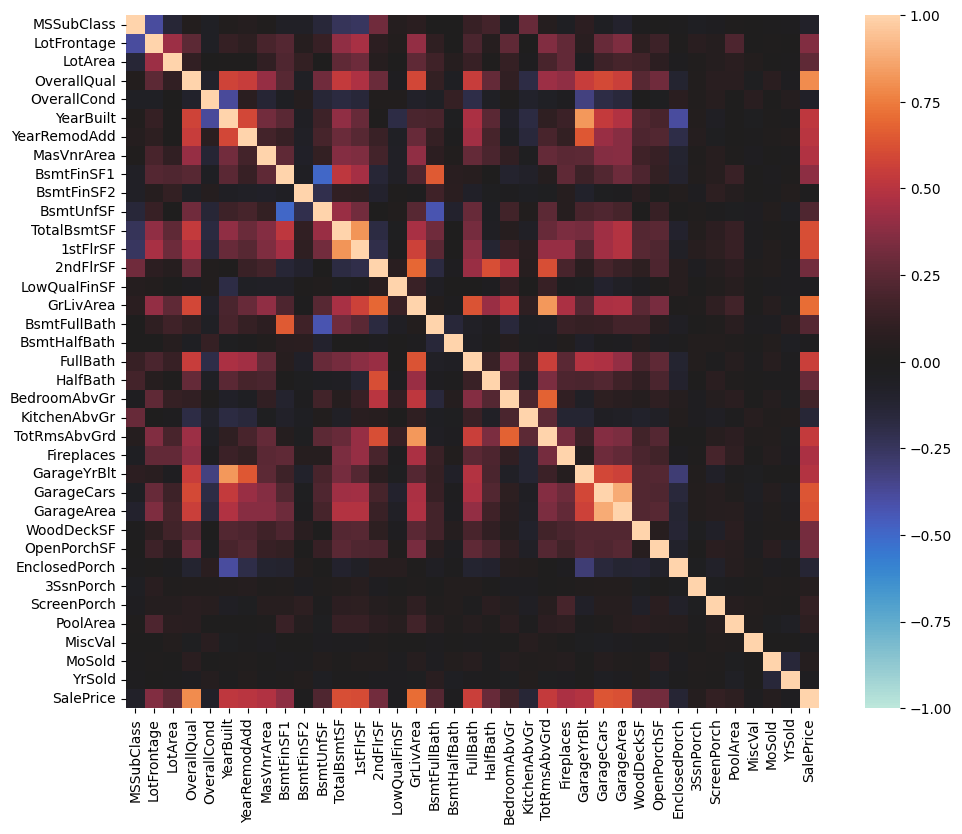

```python
# 各説明変数の相関係数のプロットをヒートマップで表現してみる (Seabornライブラリ利用)。相関が大きいものほど明るくなっている。

fig, ax = plt.subplots(figsize=(12, 9))
sns.heatmap(df_house_corr, square=True, vmax=1, vmin=-1, center=0)
##plt.savefig('seaborn_heatmap_house_price.png')
```

### 3.3 分割表とクロス集計

#### 3.3.1 分割表とクロス集計について

分割表とは、2つの変数の交差表を1つの変数で分割することで、より詳細な情報を得るための表のことである。例えば、男女と年齢層をクロス集計した場合、男女別、さらに年齢層別に分割して集計することができる。このようにすることで、より詳細な情報を得ることができる。

一方、クロス集計は、2つ以上の変数の関係を分析するために用いられる方法である。たとえば、商品の売り上げデータを地域別、性別別に分類した場合、地域別と性別別の2つの要因を同時に分析することができる。このとき、クロス集計によって、地域と性別の2つの変数が交差した集計表が作成される。

[figure not shown]

#### 3.3.1 Python crosstabを使用した分割表、クロス集計の実装例

[pandas.crosstab](https://pandas.pydata.org/pandas-docs/stable/reference/api/pandas.crosstab.html) は、クロス集計表を作成するための関数である。

【参考】 [pystyle | pandas – crosstab を使ってクロス集計表を作成する方法](https://pystyle.info/pandas-crosstab/)

```python
# サンプルデータ 「飲食店でのチップの支払い額を記録したデータ」 を読み込み (n = 244)
import pandas as pd

# CSVデータを カレントディレクトリ直下のフォルダ（一時作業領域）へダウンロードする．
!wget -nc https://raw.githubusercontent.com/MDASH-shinshu/MDASH-T-DS/main/2/resources/JJlHw.csv

# wgetしなくても，以下のGitHubから直接読み込んでも可
#df = pd.read_csv("https://git.io/JJlHw")

df = pd.read_csv('JJlHw.csv')
df.head()
```

```
--2023-04-02 06:34:16--  https://raw.githubusercontent.com/MDASH-shinshu/MDASH-T-DS/main/2/resources/JJlHw.csv
Resolving raw.githubusercontent.com (raw.githubusercontent.com)... 185.199.108.133, 185.199.109.133, 185.199.110.133, ...
Connecting to raw.githubusercontent.com (raw.githubusercontent.com)|185.199.108.133|:443... connected.
HTTP request sent, awaiting response... 200 OK
Length: 7943 (7.8K) [text/plain]
Saving to: ‘JJlHw.csv’

JJlHw.csv           100%[===================>]   7.76K  --.-KB/s    in 0s

2023-04-02 06:34:16 (81.9 MB/s) - ‘JJlHw.csv’ saved [7943/7943]
```

|  | total_bill | tip | sex | smoker | day | time | size |
| --- | --- | --- | --- | --- | --- | --- | --- |
| 0 | 16.99 | 1.01 | Female | No | Sun | Dinner | 2 |
| 1 | 10.34 | 1.66 | Male | No | Sun | Dinner | 3 |
| 2 | 21.01 | 3.50 | Male | No | Sun | Dinner | 3 |
| 3 | 23.68 | 3.31 | Male | No | Sun | Dinner | 2 |
| 4 | 24.59 | 3.61 | Female | No | Sun | Dinner | 4 |

```python
# 性別：時間帯別 の 分割表を作成

ret = pd.crosstab(df["sex"], df["time"], margins=True)
ret
```

| time sex | Dinner | Lunch | All |
| --- | --- | --- | --- |
| Female | 52 | 35 | 87 |
| Male | 124 | 33 | 157 |
| All | 176 | 68 | 244 |

```python
# 性別：時間帯に加えて曜日別 の 分割表を作成

ret = pd.crosstab(df["sex"], [df["day"], df["time"]], margins=True)
ret

# 土日はDinner、平日はランチでのチップ支払いが多い
```

| day time sex | Fri Dinner | Fri Lunch | Sat Dinner | Sun Dinner | Thur Dinner | Thur Lunch | All |
| --- | --- | --- | --- | --- | --- | --- | --- |
| Female | 5 | 4 | 28 | 18 | 1 | 31 | 87 |
| Male | 7 | 3 | 59 | 58 | 0 | 30 | 157 |
| All | 12 | 7 | 87 | 76 | 1 | 61 | 244 |

```python
# normalize=Trueまたはnormalize='all'とすると、全体を合計すると1になるように規格化する

ret = pd.crosstab([df['sex'], df['smoker']], [df['day'], df['time']], margins=True, normalize=True)
ret

# 正規化したクロス集計表によると、土日のDinnerで全体の 66%以上のチップが得られている。
# さらに、土日のDinnerで男性の非喫煙者の割合払ったチップの割合が相当大きい（全体の30%以上）であることもわかる。
```

| sex | day time smoker | Fri Dinner | Fri Lunch | Sat Dinner | Sun Dinner | Thur Dinner | Thur Lunch | All |
| --- | --- | --- | --- | --- | --- | --- | --- | --- |
| Female | No | 0.004098 | 0.004098 | 0.053279 | 0.057377 | 0.004098 | 0.098361 | 0.221311 |
|  | Yes | 0.016393 | 0.012295 | 0.061475 | 0.016393 | 0.000000 | 0.028689 | 0.135246 |
| Male | No | 0.008197 | 0.000000 | 0.131148 | 0.176230 | 0.000000 | 0.081967 | 0.397541 |
|  | Yes | 0.020492 | 0.012295 | 0.110656 | 0.061475 | 0.000000 | 0.040984 | 0.245902 |
| All |  | 0.049180 | 0.028689 | 0.356557 | 0.311475 | 0.004098 | 0.250000 | 1.000000 |

## 4. 基本統計量と相関係数 [2]

### 4.1 代表値

基本統計量は、データの集合を要約するために使用される統計学的手法のことである。その中でも代表値は、データ全体を一つの数値で代表するための方法で、平均値、中央値、最頻値が代表的なものとなる。

代表値は、単独で使用するよりも、複数の代表値を比較することでデータの傾向をより正確に分析することができる。また、分布の偏りを評価する際にも使用される。

#### 4.1.1 平均値、中央値、最頻値

- 平均値は、全てのデータを合計して、データ数で割った値である。すべてのデータを均等に扱うため、外れ値に弱いという特徴がある。
- 中央値は、データを大きさの順に並べ、中央に位置する値である。データの大きさに関係なく、データ全体の真ん中の値を代表することができる。
- 最頻値は、データの中で最も頻繁に出現する値である。頻度分布表を作成することで、最頻値を求めることができる。

[figure not shown]

- e-Stat | 家計調査 貯蓄・負債編 二人以上の世帯 詳細結果表(2021)
- [統計WEB | ジニ係数](https://bellcurve.jp/statistics/course/3798.html)

#### 4.1.2 分散、標準偏差、偏差値（特殊）

[figure not shown]

#### 4.1.3 ChickWeightサンプルデータの要約統計量

```python
# オリジナルのCSVファイルをpandasで読み込んでデータフレームdfに格納
import pandas as pd
df = pd.read_csv('ChickWeight_original.csv')
df.columns = ['weight','Time','Chick','Diet']
##df.head()
```

```python
# 日齢でデータ抽出し、要約統計量を表示してみる

df_select = df[df['Time'] == 24] # 日齢 24日の場合（変更してみよ 4の倍数であることに注意）
df_select.describe()
# count:個数、mean:算術平均、std:標準偏差、min-max:最小値-最大値、25%-50%-75%:各四分位数
```

|  | weight | Time | Chick | Diet |
| --- | --- | --- | --- | --- |
| count | 49.000000 | 49.0 | 49.000000 | 49.000000 |
| mean | 129.244898 | 24.0 | 25.653061 | 2.224490 |
| std | 34.119600 | 0.0 | 14.687794 | 1.177308 |
| min | 54.000000 | 24.0 | 1.000000 | 1.000000 |
| 25% | 108.000000 | 24.0 | 13.000000 | 1.000000 |
| 50% | 134.000000 | 24.0 | 26.000000 | 2.000000 |
| 75% | 152.000000 | 24.0 | 38.000000 | 3.000000 |
| max | 217.000000 | 24.0 | 50.000000 | 4.000000 |

### 4.2 相関と相関係数

相関とは、二つの変数の間に関係があることを示す統計学上の用語で、一方の変数が変化すると他方の変数も変化する傾向があることを指す。相関係数は、相関の強さと方向性を数値化したもので、-1から1の範囲の値をとる。ピアソンの相関係数は、二つの変数が線形関係にある場合に用いられる相関係数で、広く使われている。

相関があるからといって必ずしも因果関係があるわけではない。相関は単に関連性を示すものであり、因果関係を示すものではないからである。相関がある場合でも、それが偶然の一致である可能性もある。

因果関係を明らかにするためには、実験的手法を用いて要因と結果の因果関係を（科学的に）証明する必要がある。因果関係を示すためには、相関だけでなく、その他の要因も含めた網羅的な分析が必要なのである。

#### 4.2.1 ピアソンの相関係数

ピアソンの相関係数は、統計学において2つの変数間の線形関係の強さを表す指標の1つであり、-1から1までの値を取る。この指標は、カール・ピアソンによって開発され、広く使用されている（定義は下のスライド参照）。

ピアソンの相関係数は、以下のような性質を持ちます。

- rが1に近づくほど、XとYの間には正の相関がある。つまり、Xが増加するとYも増加する傾向がある
- rが-1に近づくほど、XとYの間には負の相関がある。つまり、Xが増加するとYが減少する傾向がある
- rが0に近づくほど、XとYの間には相関がなく、2つの変数は独立している

ピアソンの相関係数は、2つの変数間の線形関係を表すため、非線形関係がある場合には適切な指標ではない。 データに外れ値がある場合には、相関係数の値が歪んでしまう可能性がある。

[figure not shown]

#### 4.2.2 カリフォルニア住宅価格データセット（再掲） の相関係数の計算

【参考】 [scikit-learn カリフォルニア住宅価格データの前処理に関する見解](https://qiita.com/kakiuchis/items/fb25c54af77df6e394ca)

```python
# scikit-learnからカリフォルニア住宅価格データ (n = 20640) を取得

import pandas as pd
import matplotlib.pyplot as plt
import seaborn as sns
from sklearn.datasets import fetch_california_housing
dataset = fetch_california_housing()
##print(dataset.DESCR)
```

```python
# DataFrameで実データを確認

df = pd.DataFrame(dataset.data, columns=dataset.feature_names)
df['Price'] = dataset.target
df.head()
```

|  | MedInc | HouseAge | AveRooms | AveBedrms | Population | AveOccup | Latitude | Longitude | Price |
| --- | --- | --- | --- | --- | --- | --- | --- | --- | --- |
| 0 | 8.3252 | 41.0 | 6.984127 | 1.023810 | 322.0 | 2.555556 | 37.88 | -122.23 | 4.526 |
| 1 | 8.3014 | 21.0 | 6.238137 | 0.971880 | 2401.0 | 2.109842 | 37.86 | -122.22 | 3.585 |
| 2 | 7.2574 | 52.0 | 8.288136 | 1.073446 | 496.0 | 2.802260 | 37.85 | -122.24 | 3.521 |
| 3 | 5.6431 | 52.0 | 5.817352 | 1.073059 | 558.0 | 2.547945 | 37.85 | -122.25 | 3.413 |
| 4 | 3.8462 | 52.0 | 6.281853 | 1.081081 | 565.0 | 2.181467 | 37.85 | -122.25 | 3.422 |

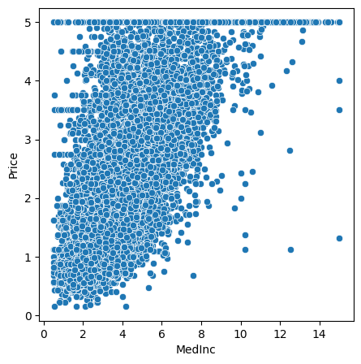

```python
# MedInc(ブロックの所得中央値), Price（住宅価格） の間で散布図を生成してみる (Seabornライブラリ利用)

plt.rcParams["figure.figsize"] = (5, 5)
sns.scatterplot(data=df, x='MedInc', y='Price')
```

```python
# Pearsonの相関係数を計算（pandas corr） 2ペアのみ
df_house_corr=df.loc[:,['MedInc','Price']].corr()
df_house_corr
```

|  | MedInc | Price |
| --- | --- | --- |
| MedInc | 1.000000 | 0.688075 |
| Price | 0.688075 | 1.000000 |

```python
# Pearsonの相関係数を計算（pandas corr） 全てのペア
df_house_corr=df.corr()
df_house_corr
```

|  | MedInc | HouseAge | AveRooms | AveBedrms | Population | AveOccup | Latitude | Longitude | Price |
| --- | --- | --- | --- | --- | --- | --- | --- | --- | --- |
| MedInc | 1.000000 | -0.119034 | 0.326895 | -0.062040 | 0.004834 | 0.018766 | -0.079809 | -0.015176 | 0.688075 |
| HouseAge | -0.119034 | 1.000000 | -0.153277 | -0.077747 | -0.296244 | 0.013191 | 0.011173 | -0.108197 | 0.105623 |
| AveRooms | 0.326895 | -0.153277 | 1.000000 | 0.847621 | -0.072213 | -0.004852 | 0.106389 | -0.027540 | 0.151948 |
| AveBedrms | -0.062040 | -0.077747 | 0.847621 | 1.000000 | -0.066197 | -0.006181 | 0.069721 | 0.013344 | -0.046701 |
| Population | 0.004834 | -0.296244 | -0.072213 | -0.066197 | 1.000000 | 0.069863 | -0.108785 | 0.099773 | -0.024650 |
| AveOccup | 0.018766 | 0.013191 | -0.004852 | -0.006181 | 0.069863 | 1.000000 | 0.002366 | 0.002476 | -0.023737 |
| Latitude | -0.079809 | 0.011173 | 0.106389 | 0.069721 | -0.108785 | 0.002366 | 1.000000 | -0.924664 | -0.144160 |
| Longitude | -0.015176 | -0.108197 | -0.027540 | 0.013344 | 0.099773 | 0.002476 | -0.924664 | 1.000000 | -0.045967 |
| Price | 0.688075 | 0.105623 | 0.151948 | -0.046701 | -0.024650 | -0.023737 | -0.144160 | -0.045967 | 1.000000 |

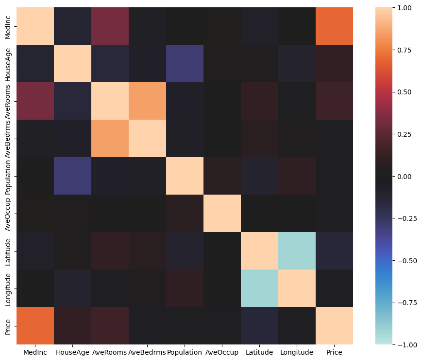

```python
# 各説明変数の相関係数のプロットをヒートマップで表現してみる (Seabornライブラリ利用)。相関が大きいものほど明るくなっている。
fig, ax = plt.subplots(figsize=(12, 9))
sns.heatmap(df_house_corr, square=True, vmax=1, vmin=-1, center=0)
##plt.savefig('seaborn_heatmap_house_price.png')
```

Price（住宅価格）と正の相関が強いのは、MedInc(ブロックの所得中央値)ぐらいしかなさそうだ。